# SCEM Summative Section B

Averil kan (ov21312)

30/11/2021

# Section B

## B.1

### (a)

Write a function called “c_prob_person_given_alarm” which gives ϕ as a function of p0,p1 and q.

```r
c_prob_person_given_alarm <- function(p_0,p_1,q){
  q*p_1/(p_1*q+p_0*(1-q))
}
```

### (b)

Compute ϕ via setting p0 = 0.05, p1 = 0.95 and q = 0.1.

```r
p_0 = 0.05
p_1 = 0.95
q = 0.1
c_prob_person_given_alarm(p_0,p_1,q)
```

```
## [1] 0.6785714
```

### (c)

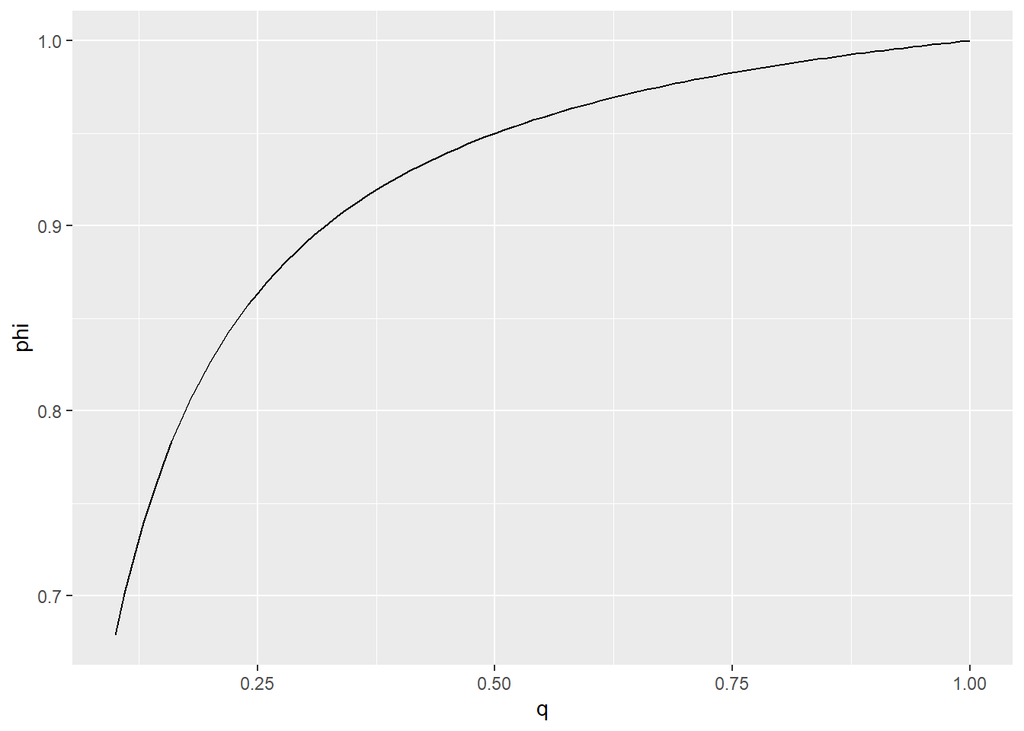

```r
q = seq(0.1,1,0.01)

vary_q = data.frame(q) %>%
  mutate(phi=map_dbl(.x=q,.f=~c_prob_person_given_alarm(p_0,p_1,.x))) %>%
  ggplot(aes(x=q,y=phi)) +
  geom_line()
vary_q
```

## B.2

### (b)

An expression for the expectation of X in terms of α,β,γ.
$$\begin{align}
E[Y] &= 0 \cdot P(Y=0) +1 \cdot P(Y=1) +2 \cdot P(Y=2) +5 \cdot P(Y=5) \\
&= 0 \cdot (1-\alpha-\beta-\gamma) +1 \cdot \alpha +2 \cdot \beta +5 \cdot \gamma \\
&= 1 \cdot \alpha +2 \cdot \beta +5 \cdot \gamma \\
\end{align}$$

### (c)

An expression for the population variance of X in terms of α,β,γ.

$$\begin{align}
Var(X) &= E[X^2]-E[X]^2 \\
&= \alpha + 4\beta +25 \gamma - (\alpha+2\beta+5\gamma)^2 \\
\end{align}$$

### (d)

An expression for the expectation of the random variable X in terms of α,β,γ.
$$\begin{align}
E[\overline{X}]&=E\Bigg[\frac{1}{n} \sum_{i=1}^{n}X_{i}\Bigg]\\
&=\frac{1}{n}\sum_{i=1}^{n}E[X_{i}]\\
&=\frac{1}{n} \cdot n \cdot (\alpha+2\beta+5\gamma) \\
&=\alpha+2\beta+5\gamma \\
\end{align}$$

### (e)

An expression for the population variance of the random variable X in terms of α,β,γ,n:
$$\begin{align}
Var(\overline{X}) &= Var\Bigg(\frac{1}{n} \sum_{i=1}^{n}X_{i}\Bigg)\\
&=\sum_{i=1}^{n}Var\Big(\frac{1}{n}\cdot X_{i}\Big)\\
&=\sum_{i=1}^{n} \frac{1}{n^2} Var\Big(X_{i}\Big)\\
&=\frac{n}{n^2} \cdot [\alpha + 4\beta +25 \gamma - (\alpha+2\beta+5\gamma)^2] \\
&=\frac{1}{n} \cdot [\alpha + 4\beta +25 \gamma - (\alpha+2\beta+5\gamma)^2]\\
\end{align}$$

### (f)

```r
set.seed(0)

sample_X_0125 <- function(alpha,beta,gamma,n){
  sample_X<-data.frame(U=runif(n))%>%
  mutate(X=case_when(
  (0<=U)&(U<alpha)~1,
  (alpha<=U)&(U<(alpha+beta))~2,
  ((alpha+beta)<=U)&(U<=(alpha+beta+gamma))~5,
  ((alpha+beta+gamma)<=U)&(U<=(1))~0)) %>%
  pull(X) %>%
  replace_na(0)
  return(sample_X)
}

alpha = 0.1
beta = 0.2
gamma = 0.3

# (g)

x <- sample_X_0125(alpha,beta,gamma,10000)
X_bar <- mean(x)
sample_variance <- var(x)
X_bar
```

```
## [1] 2.0069
```

```r
sample_variance
```

```
## [1] 4.405093
```

### (h)

```r
set.seed(0)

num_trials <- 10000
n <- 100
alpha <- 0.1
beta <- 0.2
gamma <- 0.3

simulation_df<-crossing(trial=seq(num_trials), sample_size=n) %>%
  mutate(simulation=pmap(.l=list(trial,sample_size),.f=~sample_X_0125(alpha,beta,gamma,.y))) %>%
  mutate(X_bar=as.numeric(map(.x=simulation,.f=~mean(.x))))
```

### (i)

Generate a histogram plot which displays the behavior of the sample mean within your simulation study.

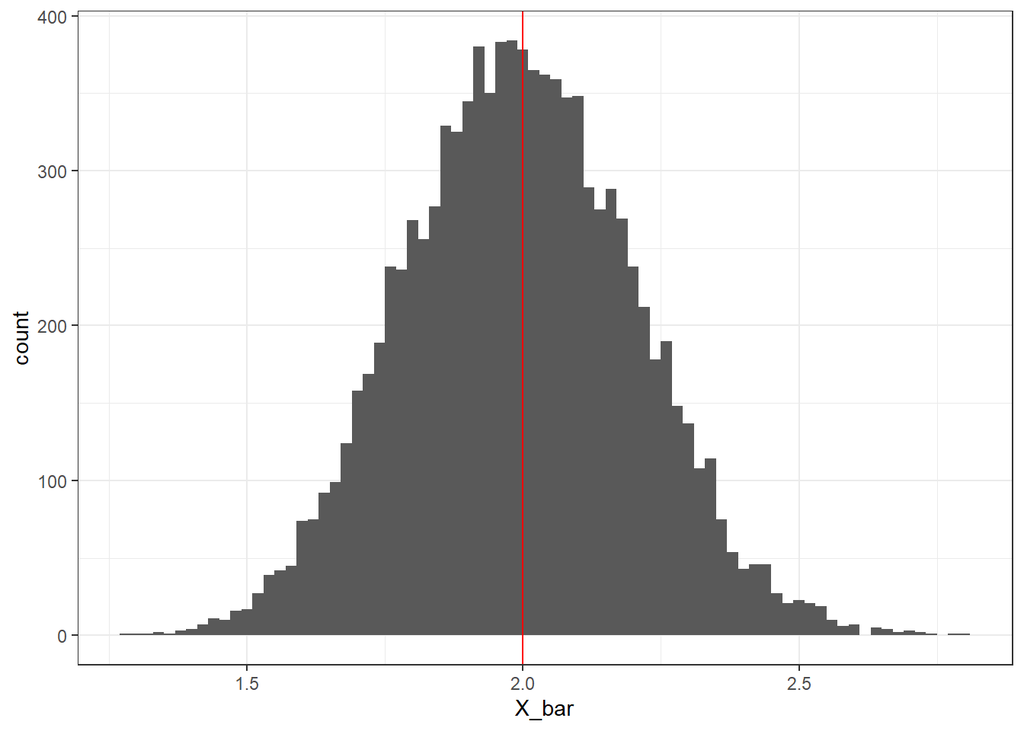

```r
simulation_histogram <- simulation_df %>%
  ggplot(aes(x = X_bar)) +
  geom_histogram(binwidth = 0.02) +
  geom_vline(xintercept = 2, color = "red") +
  theme_bw() +
  labs()

simulation_histogram
```

### (j)

Compute numerical value of expectation and variance from simulation study.

```r
X_bars <- simulation_df %>%
  pull(X_bar)

#numerical value of expectation from simulation study:
E_X_bar <- mean(X_bars)
#numerical value of variance from simulation study:
Var_X_bar <- var(X_bars)
```

### (k)

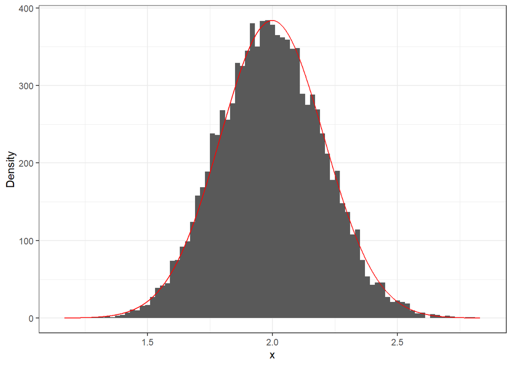

```r
n=seq(E_X_bar-4*sqrt(Var_X_bar),E_X_bar+4*sqrt(Var_X_bar),0.0001)
standardGaussianSample <- dnorm(n,E_X_bar,sqrt(Var_X_bar))

simulation_histogram_and_line <- simulation_df %>%
  ggplot(aes(x = X_bar)) +
  geom_histogram(binwidth = 0.02) +
  labs(x="x",y="Density") +
  geom_line(data= data.frame(x=n, y=standardGaussianSample*200), aes(x=x, y=y), color = "red") +
  theme_bw()

simulation_histogram_and_line
```

central limit theorm

## B.3

### (a)

Formula for the the population mean and variance of an exponential random variable X with parameter λ:

let X ~ Exponential(λ). Expected value can be found by using integration by parts:
$$\begin{align}
E[X]&= \int_{0}^{\infty} x \lambda e^{- \lambda x}dx \\
&= \frac{1}{\lambda} \int_{0}^{\infty} y e^{- y}dy \\
&= \frac{1}{\lambda} \bigg[-e^{-y}-ye^{-y} \bigg]_{0}^{\infty} \\
&= \frac{1}{\lambda}\\
\\
\\
\\
E[X^2] &= \int_{0}^{\infty} x^2 \lambda e^{- \lambda x}dx\\
&= \frac{1}{\lambda^2} \int_{0}^{\infty} y^2 e^{- y}dy \\
&= \frac{1}{\lambda^2} \bigg[-2e^{-y}-2ye^{-y}-y^2e^{-y} \bigg]_{0}^{\infty} \\
&= \frac{2}{\lambda^2}
\end{align}$$
Thus Var(X):
$$\begin{align}
Var(x) &=E[X^2]-(E[X])^2 \\
&=\frac{2}{\lambda^2}-\frac{1}{\lambda^2} \\
&=\frac{1}{\lambda^2}
\end{align}$$

### (c)

The maximum likelihood estimate for λ0 is:
$$\begin{align}
\hat{ \lambda } &= arg \max_{ \lambda } l ( \lambda: x_{1},...,x_{n}) \\
\frac{d}{d \lambda }l ( \lambda: x_{1} ,...,x_{n}) &=0 \\
\frac{d}{d \lambda }l ( \lambda: x_{1} ,...,x_{n}) &= \frac{d}{d \lambda }\Big(n ln(\lambda)- \lambda \sum_{i=1}^{n}x_{i}\Big) \\
&=\frac{n}{ \lambda }-\sum_{i=1}^{n}x_{i} \\
\lambda_{0} &= \frac{n}{ \sum_{i=1}^{n}x_{i} }
\end{align}$$

### (d)

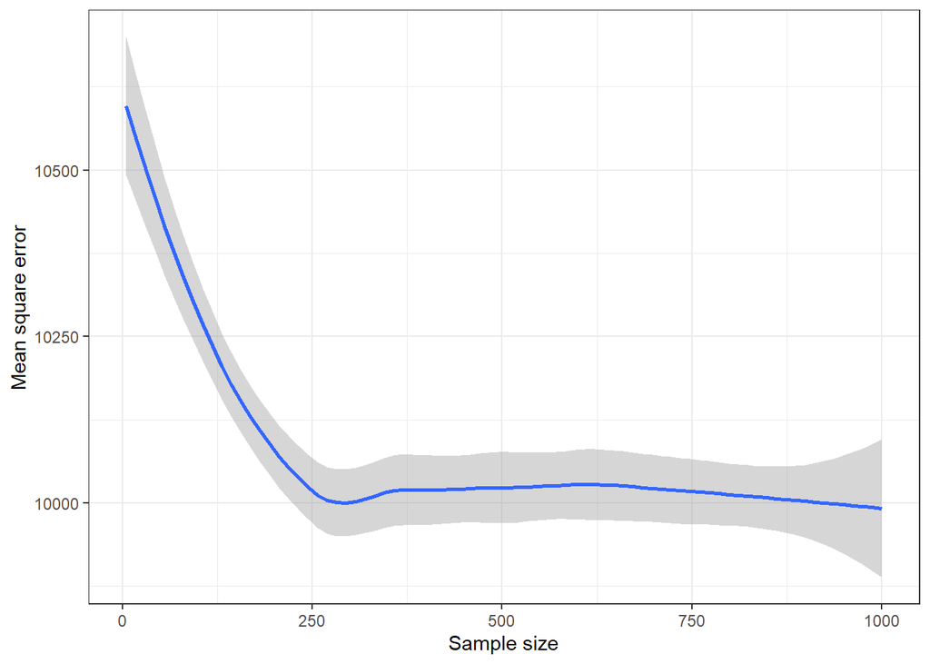

```r
set.seed(0)
num_trials_per_sample_size<-100
min_sample_size<-5
max_sample_size<-1000
sample_size_inc<-5
lambda_0<-0.01

exp_simulation_df<-crossing(trial=seq(num_trials_per_sample_size),
  sample_size=seq(min_sample_size,max_sample_size,sample_size_inc)) %>%
# create data frame of all pairs of sample_size and trial
  mutate(simulation=pmap(.l=list(trial,sample_size),
                         .f=~rexp(.y,rate = lambda_0))) %>%
# simulate sequences of Gaussian random variables
  mutate(lambda_mle=map_dbl(.x=simulation,.f=mean))%>%
# compute the sample sd
  group_by(sample_size) %>%
  summarise(msq_error=mean((lambda_mle-lambda_0)^2))

exp_simulation_df %>%
  ggplot(aes(x=sample_size,y=msq_error))+
  geom_smooth()+
  theme_bw()+
  xlab("Sample size")+ylab("Mean square error")
```

```r
exp_simulation_df %>%
  head(3)
```

```
## # A tibble: 3 x 2
##   sample_size msq_error
##         <dbl>     <dbl>
## 1           5    11817.
## 2          10    10520.
## 3          15    11012.
```

```r
birds_data_original <- read.csv("./bird_data_EMATM0061.csv",fill=1)
dim(birds_data_original)
```

```
## [1] 15064     2
```

```r
birds_data_original %>%
  head(10)
```

```
##    Time       Species
## 1    30        Magpie
## 2    60     Chaffinch
## 3    90        Magpie
## 4   180 Collared Dove
## 5   750     Blackbird
## 6  1020        Magpie
## 7  1110 Collared Dove
## 8  1320     Chaffinch
## 9  1320     Blackbird
## 10 1620     Chaffinch
```

### (e)

Compute and display the maximum likelihood estimate of the rate parameter λˆMLE.

```r
birds_data_original <- birds_data_original %>%
  mutate(time_diffs=lead(Time)-Time)

time_diffs <- birds_data_original %>%
  pull(time_diffs)

lambda_MLE <- 1/mean(time_diffs,na.rm = TRUE)
lambda_MLE
```

```
## [1] 0.004982387
```

### (f)

Give a confidence interval for λ0 with a confidence level of 95%.

```r
alpha <- 0.05
z_alpha <- qnorm(1-alpha/2)
n <- length(time_diffs)-1
n_mean <- mean(time_diffs,na.rm=T)
l <- (1/n_mean)*(1-z_alpha/sqrt(n))
u <- (1/n_mean)*(1+z_alpha/sqrt(n))

c(l,u)
```

```
## [1] 0.004902820 0.005061953
```